# Portfolio Optimization Using Mean-Variance and CVaR Models

# Overview

In this project, we aim to optimize a portfolio of 100 stocks form various sectors using two different optimization models: **Mean-Variance Optimization** and **Conditional Value at Risk (CVaR)** Optimization. The goal is to construct a portfolio that maximizes returns while minimizing risk.

## The selection criterion

To ensure a well-diversified and robust portfolio, the following crteria were usde to select the 100 srocks:

- **Market Capitalization:** The stock list covers some of the largest companies by market capitalization to ensure that the stocks are among the most widely traded in the market.
- **Widely Recognized Companies:** These companies are well-known and have a significant impact on their industires. They are the leaders or major players in their indutries.
- **Sector Representation:** The list covers a broad range of sectors, including technology, healthcare, finance, consumer goods, energy, industrials, and utilities. This helps ensure that the portfolio analysis covers different parts of the economy.
- **Liquidity:** The stocks listed have a high volume of shares traded daily. This ensures that the stocks are easily tradable and that the market for these stocks is active.
- **Financial Stability and Performance:** The companies have a strong financial performance over years, stability, and positive outlooks. They are generally considered to be reliable investments.

# 1. Data Collection

We Downloaded historical daily closing prices for the selected 100 stocks from Yahoo Finance, spanning from January 1, 2018 to July 15, 2024. The list of the 100 stocks is in the **Appendix**.

```python
import yfinance as yf
import pandas as pd
import numpy as np
import matplotlib.pyplot as plt
import seaborn as sns
import cvxpy as cvx
from numpy import matrix
from cvxpy import *
```

```python
# List the 100 stocks
tickers = [
    'AAPL', 'MSFT', 'GOOGL', 'AMZN', 'META', 'TSLA', 'BRK-B', 'JNJ', 'V', 'WMT',
    'JPM', 'UNH', 'NVDA', 'HD', 'PG', 'MA', 'DIS', 'PYPL', 'VZ', 'ADBE',
    'CMCSA', 'NFLX', 'XOM', 'KO', 'CSCO', 'PFE', 'INTC', 'MRK', 'PEP', 'T',
    'ABT', 'ABBV', 'ACN', 'TMO', 'NKE', 'CRM', 'MDT', 'WFC', 'MCD', 'AMGN',
    'QCOM', 'COST', 'BMY', 'NEE', 'HON', 'TXN', 'UNP', 'LIN', 'LLY', 'AVGO',
    'IBM', 'SBUX', 'CVX', 'GS', 'BLK', 'RTX', 'GILD', 'BKNG', 'ISRG', 'NOW',
    'CAT', 'AMD', 'DE', 'LMT', 'SPGI', 'SCHW', 'MS', 'PLD', 'TGT', 'INTU',
    'GE', 'ADP', 'ELV', 'MDLZ', 'AXP', 'MU', 'MO', 'CI', 'MMM', 'CL', 'DUK',
    'PNC', 'SO', 'SYK', 'C', 'BDX', 'ITW', 'BSX', 'FIS', 'EL', 'HUM', 'ZTS',
    'DHR', 'AMT', 'ILMN', 'MRNA', 'ORCL', 'COP', 'SHW', 'REGN'
]
```

```python
# Funtion to download the close prices for each stock
def download_data(tickers, start, end):
    data = {}
    for ticker in tickers:
        stock_data = yf.Ticker(ticker).history(period='1d', start=start, end=end)['Close']
        data[ticker] = stock_data
    df = pd.DataFrame(data)
    return df
```

```python
# Set the start and end date
start_date = '2018-1-1'
end_date = '2024-7-15'
```

```python
# Download data
df = download_data(tickers, start_date, end_date)
```

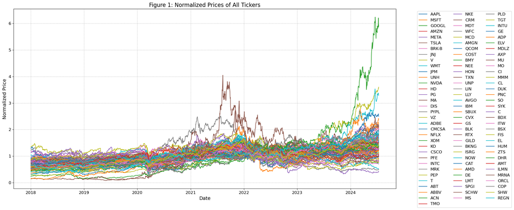

```python
# Plot the trade
plt.figure(figsize=(21, 9))
for ticker in df.columns:
    normalized_prices = df[ticker] / np.mean(df[ticker])
    plt.plot(normalized_prices, label=ticker)

plt.title('Figure 1: Normalized Prices of All Tickers', fontsize=16)
plt.xlabel('Date', fontsize=14)
plt.ylabel('Normalized Price', fontsize=14)
plt.legend(df.columns, bbox_to_anchor=(1.05, 1), loc='upper left', ncol=3, fontsize=12)
plt.xticks(fontsize=12)
plt.yticks(fontsize=12)
plt.grid(True, linestyle='--', alpha=0.7)
plt.tight_layout()
plt.show()
```

#### Key observations include:

1. **General Stability and Growth:** Most stocks were stable until early 2020, after which there was increased volatility and divergence in prices, coinciding with the COVID-19 pandemic.
2. **Performance Variability:** While many stocks show moderate growth, a few have significantly outperformed, especially from 2020 onwards.
3. **Sector Representation:** The stocks cover a wide range of sectors, providing insights into the performance of different parts of the economy.
4. **Investment Insights:** The normalization of prices highlights relative performance, aiding in the identification of potential high-performing stocks.

Overall, the plot illustrates the historical performance and sectoral impact on a diversified portfolio over the specified period.

# 2. Mean-Variance Optimization

### Introduction

Mean-Variance Optimization, based on Harry Markowitz's Modern Portfolio Theory, aims to maximize portfolio returns for a given level of risk by diversifying investments.

### Theoretical Background

- $x_i$ is the share of your portfolio that is allocated to stock $i$
- The returns follow a multivariate Normal distribution, i.e., r~$N(\mu,\Sigma)$
- $R$ is the mininum return you want to have

\begin{align} \text{Minimize} \quad \frac{1}{2} x^T & \Sigma x\\ \text{s.t.}\quad \mu^T x &\geq R\\ \sum_{i}^{}x_i&=1\\ x&\geq0 \end{align}

## 2.1 Portfolio Optimization

### Methodology

1. **Calculate Daily Returns:**
- The daily percentage changes in the closing prices of the stocks were calculated to obtain their returns.
1. **Compute Mean Returns and Covariance Matrix:**
- The mean returns represent the average returns for each stock over the period.
- The covariance matrix represents the degree to which the returns of the stocks move together. It is a crucial element in assessing the risk of the portfolio.
1. **Define the Optimization Problem:**
- We defined the portfolio's total risk as the weighted sum of individual stock risks, considering their covariances.
- The expected return of the portfolio is the weighted sum of the individual stock returns.
- The optimization problem was set to minimize the portfolio's risk while ensuring that the expected return met a specified target.
1. **Solve the Optimization Problem:**
- Using convex optimization, the problem was solved to find the optimal weights for each stock in the portfolio.

```python
# Calculate daily returns
returns = df.pct_change().dropna()

# Compute mean returns and covariance matrix
mean_returns = returns.mean().values
cov_matrix = returns.cov().values

# Define the optimization variables
x = cvx.Variable(len(tickers))

# Define the risk and return
risk = cvx.quad_form(x, cov_matrix)
portfolio_return = mean_returns @ x

# Define the expected return
target_return = 0.15 / 250

# Define the constraints and optimization problem
constraints = [portfolio_return >= target_return, cvx.sum(x) == 1, x >= 0]
prob = Problem(Minimize(risk), constraints)
```

```python
# Solve the problem
prob.solve()

# The optimal weights
optimal_weights = x.value
```

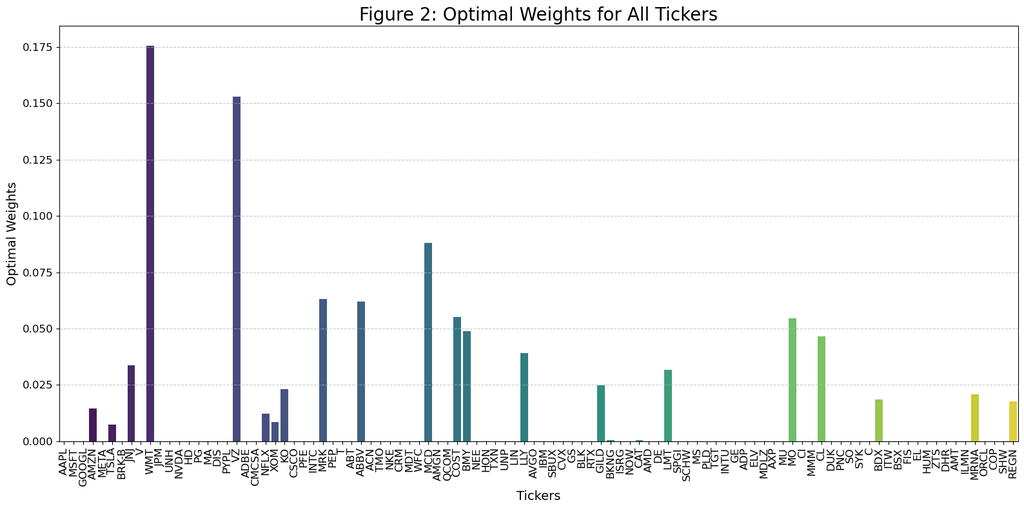

```python
# Plot the optimal weights for all tickers
plt.figure(figsize=(16, 8))
sns.barplot(x=df.columns, y=optimal_weights, palette='viridis')
plt.xlabel('Tickers', fontsize=14)
plt.ylabel('Optimal Weights', fontsize=14)
plt.title('Figure 2: Optimal Weights for All Tickers', fontsize=20)
plt.xticks(rotation=90, fontsize=12)
plt.yticks(fontsize=12)
plt.grid(axis='y', linestyle='--', alpha=0.7)
plt.tight_layout()
plt.show()
```

```python
# Filter and print the tickers with weight greater than or equal to 0.1%
overweight_stocks = [(tickers[i], optimal_weights[i]) for i in range(len(tickers)) if optimal_weights[i] >= 0.001]

print("Tickers with weights >= 0.1%:")
for ticker, weight in overweight_stocks:
    print(f"{ticker}: {weight}")
```

```
Tickers with weights >= 0.1%:
AMZN: 0.014405986028719243
TSLA: 0.007390399698943955
JNJ: 0.03366402227008312
WMT: 0.1755854692769257
VZ: 0.15285582026304417
NFLX: 0.012136916552051727
XOM: 0.008433643444663321
KO: 0.02317707474264899
MRK: 0.06321721092927986
ABBV: 0.06208506522856025
MCD: 0.08812739830911803
COST: 0.055100858464768074
BMY: 0.04894181099615282
LLY: 0.038980773221164965
GILD: 0.024905914640954655
LMT: 0.03162815818760185
MO: 0.05467929123478692
CL: 0.04645028378968737
BDX: 0.018564931785048328
MRNA: 0.02091173078801253
REGN: 0.01771697733879004
```

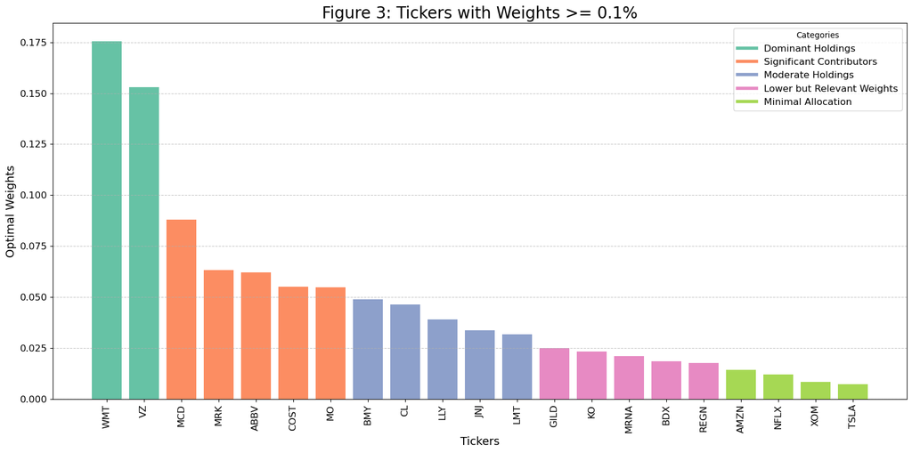

```python
# Plot overweight stocks
overweight_stocks_sorted = sorted(overweight_stocks, key=lambda x: x[1], reverse=True)
plotted_ticker = [ticker for ticker, weight in overweight_stocks_sorted]
plotted_weight = [weight for ticker, weight in overweight_stocks_sorted]

categories = {
    "Dominant Holdings": ["WMT", "VZ"],
    "Significant Contributors": ["MCD", "MRK", "ABBV", "COST", "MO"],
    "Moderate Holdings": ["CL", "BMY", "LLY", "JNJ", "LMT"],
    "Lower but Relevant Weights": ["GILD", "KO", "MRNA", "BDX", "REGN"],
    "Minimal Allocation": ["AMZN", "NFLX", "XOM", "TSLA"]
}
colors = {
    "Dominant Holdings": sns.color_palette("Set2")[0],
    "Significant Contributors": sns.color_palette("Set2")[1],
    "Moderate Holdings": sns.color_palette("Set2")[2],
    "Lower but Relevant Weights": sns.color_palette("Set2")[3],
    "Minimal Allocation": sns.color_palette("Set2")[4]
}


ticker_colors = []
for ticker in plotted_ticker:
    for category, tickers in categories.items():
        if ticker in tickers:
            ticker_colors.append(colors[category])
            break


plt.figure(figsize=(16, 8))
bars = plt.bar(plotted_ticker, plotted_weight, color=ticker_colors)

plt.xlabel('Tickers', fontsize=14)
plt.ylabel('Optimal Weights', fontsize=14)
plt.title('Figure 3: Tickers with Weights >= 0.1%', fontsize=20)
plt.xticks(rotation=90, fontsize=12)
plt.yticks(fontsize=12)
plt.grid(axis='y', linestyle='--', alpha=0.7)

legend_patches = [plt.Line2D([0], [0], color=color, lw=4) for color in colors.values()]
legend_labels = colors.keys()
plt.legend(legend_patches, legend_labels, title='Categories', fontsize=12)

plt.tight_layout()
plt.show()
```

### Outcomes:

#### 1. Weights Allocation (Figure 2):

This bar chart displays the optimal weights assigned to all 100 selected stocks in the portfolio using Mean-Variance Optimization. Each bar represents a stock, and its height indicates the proportion of the total portfolio that should be invested in that stock.

- **Near-Zero Weights:** Some stocks have weights that are close to zero, indicating that these stocks do not contribute significantly to achieving the investing target.
- **Overweight Stocks:** Stocks with higher weights are considered more favorable in the portfolio. *Walmart (WMT)* and *Verizon (VZ)* stand out with the highest weights, pproximately *17.56%* and *15.29%*, respectively. This suggests their stable and strong performance during the period considered. Other stocks with notable weights include *McDonald's (MCD)*, *Merck (MRK)*, and *AbbVie (ABBV)*, also indicating their strong performance and lower risk.

  Overweight Stocks list (Figure 3):
  1. Walmart (WMT) - 17.56%
  2. Verizon (VZ) - 15.29%
  3. McDonald's (MCD) - 8.81%
  4. Merck (MRK) - 6.32%
  5. AbbVie (ABBV) - 6.21%
  6. Costco (COST)**: 5.51%
  7. Altria (MO)**: 5.47%
  8. Bristol-Myers Squibb (BMY)**: 4.89%
  9. Colgate-Palmolive (CL)**: 4.64%
  10. Eli Lilly (LLY)**: 3.90%
  11. Johnson & Johnson (JNJ)**: 3.37%
  12. Lockheed Martin (LMT)**: 3.16%
  13. Gilead Sciences (GILD)**: 2.49%
  14. Coca-Cola (KO)**: 2.32%
  15. Moderna (MRNA)**: 2.09%
  16. Becton, Dickinson and Company (BDX)**: 1.86%
  17. Regeneron Pharmaceuticals (REGN)**: 1.77%
  18. Amazon (AMZN)**: 1.44%
  19. Netflix (NFLX)**: 1.21%
  20. ExxonMobil (XOM)**: 0.84%
  21. Tesla (TSLA)**: 0.74%

## 2.2 Portfolio Simulation

### Introduction

In this section, we simulate the portfolio's value over 252 trading days (approximately one year) to evaluate the potential future performance of the optimized portfolio and understand its distribution of possible outcomes.

### Methodology

1. **Simulation Parameters**:
- We conduct 10,000 simulations, each representing a different possible future scenario.
- The simulation period is set to 252 trading days, representing one year.
1. **Initial Portfolio Value**:
- The initial value of the portfolio is set to 1 for simplicity, allowing us to focus on the relative changes in value.
1. **Generate Random Daily Returns**:
- For each simulation, random daily returns are generated based on the mean returns and covariance matrix of the portfolio.
1. **Calculate Portfolio Value**:
- The daily portfolio returns are calculated using the optimized weights obtained from Mean-Variance Optimization.
- The portfolio value at the end of the simulation period is computed by compounding the daily returns.
1. **Histogram of Portfolio Values**:
- The results of the simulations are visualized using a histogram to show the distribution of the portfolio values after 252 trading days.

```python
# Set the numebr of simulations and trading days
num_simulations = 10000
num_trading_days = 252

# Initial invest value
initial_portfolio_value = 1
```

```python
# Convert mean returns and covariance matrix for simulation
mean_returns_sim = np.array(mean_returns)
cov_matrix_sim = np.array(cov_matrix)
```

```python
# Simulate
simulated_portfolio_values = np.zeros(num_simulations)

for i in range(num_simulations):
    # Generate random daily returns based on the mean and covariance
    simulated_daily_returns = np.random.multivariate_normal(mean_returns_sim, cov_matrix_sim, num_trading_days)

    # Calculate the daily portfolio returns using the optimized weights
    portfolio_daily_returns = np.dot(simulated_daily_returns, optimal_weights)

    # Calculate the portfolio value at the end of the period
    portfolio_value = initial_portfolio_value * np.prod(1 + portfolio_daily_returns)
    simulated_portfolio_values[i] = portfolio_value
```

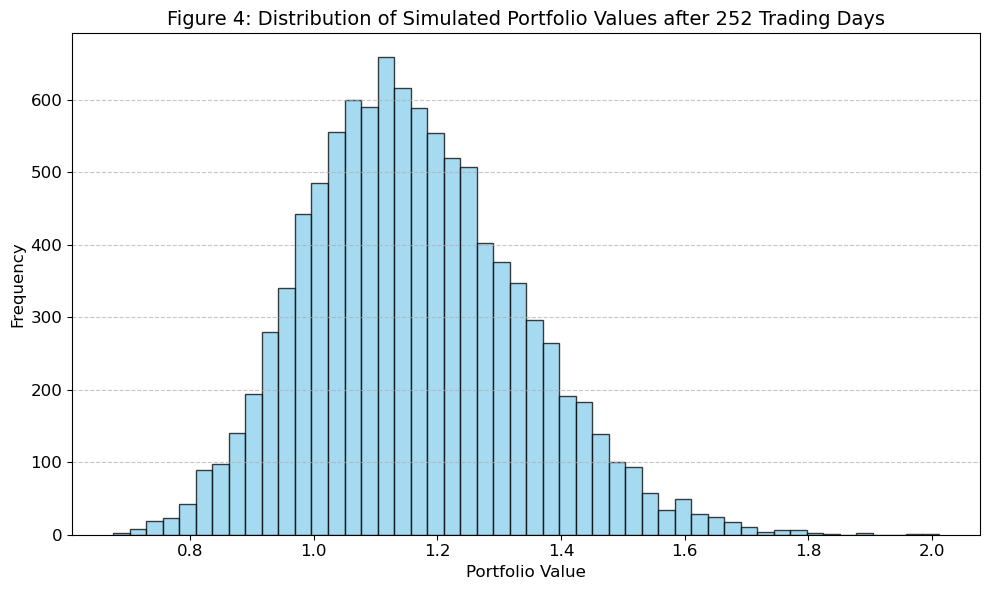

```python
# Plot the histogram of the portfolio values
plt.figure(figsize=(10, 6 ))
plt.hist(simulated_portfolio_values, bins=50, edgecolor='black', alpha=0.75, color='skyblue')
plt.xlabel('Portfolio Value', fontsize=12)
plt.ylabel('Frequency', fontsize=12)
plt.title('Figure 4: Distribution of Simulated Portfolio Values after 252 Trading Days', fontsize=14)
plt.grid(axis='y', linestyle='--', alpha=0.7)
plt.xticks(fontsize=12)
plt.yticks(fontsize=12)
plt.tight_layout()
plt.show()
```

```python
# Statistics summary
mean_simulated_value = np.mean(simulated_portfolio_values)
std_dev_simulated_value = np.std(simulated_portfolio_values)
print(f"Mean Portfolio Value: {mean_simulated_value}")
print(f"Standard Deviation of Portfolio Value: {std_dev_simulated_value}")
```

```
Mean Portfolio Value: 1.1624433135114756
Standard Deviation of Portfolio Value: 0.17356877800106557
```

#### Outcomes:

#### 1. Histogram Explanation (Figure 4):

- **Distribution Shape**: The histogram shows the distribution of the portfolio values at the end of the simulation period. The distribution is approximately normal, centered around the mean portfolio value.
- **Most Likely Outcomes**: The majority of the simulated portfolio values fall within a range close to the mean of 1.16, indicating that the portfolio is expected to increase its value over the year and chieve the objective of 15% increase.
- **Potential Extreme Outcomes**: The tails of the distribution represent less likely outcomes, where the portfolio could either significantly increase or decrease in value, representing the risks.

#### Conclusion

- The simulation results reflect the effectiveness of the Mean-Variance Optimization model in constructing a portfolio that balances return and risk. By simulating different market scenarios, we gain valuable insights into the potential performance and stability of the portfolio over time. This analysis supports informed decision-making and strategic investment planning.

# 3. Conditional Value-at-Risk (CVaR) Optimization

### Introduction

Conditional Value-at-Risk (CVaR), also known as Expected Shortfall, is a risk measure that provides an estimate of the expected loss given that a certain threshold (Value-at-Risk or VaR) is exceeded. Unlike VaR, which only considers the threshold loss, CVaR accounts for the tail losses beyond VaR, making it a more comprehensive measure of risk.

### Theoretical Background

From the provided text, the CVaR for a given confidence level $\alpha$ is defined as:

$$ \text{CVaR}_\alpha(X) = \frac{1}{1 - \alpha} \int_{\alpha}^1 \text{VaR}_u(X) \, du $$

To minimize CVaR, we use the following optimization model:

$$ \min_{\gamma, x} \gamma + \frac{1}{1 - \alpha} \sum_{s=1}^S z_s $$

Subject to: $$ z_s \geq f(x, y_s) - \gamma,\\ \quad z_s \geq 0, \\ \quad \forall s = 1, \ldots, S $$

Where:

- $\gamma$ is a decision variable representing the VaR.
- $x$ is the vector of portfolio weights.
- $z_s$ are auxiliary variables to ensure that the CVaR constraints are satisfied.
- $f(x, y_s)$ is the loss function, which in this context represents the portfolio loss.

### Methodology

1. **Define Optimization Variables**:
- We define $\gamma$, $x$, and $z_s$ as optimization variables.
1. **Set Constraints**:
- The sum of the portfolio weights must equal 1.
- Portfolio weights must be non-negative.
- Auxiliary variables $z_s$ must be non-negative.
- The CVaR definition constraint ensures that $z_s$ are greater than or equal to the portfolio losses minus $\gamma$.
1. **Objective Function**:
- Minimize the sum of $\gamma$ and the average of the $z_s$ values divided by $(1 - \alpha)$.

```python
tickers = [
    'AAPL', 'MSFT', 'GOOGL', 'AMZN', 'META', 'TSLA', 'BRK-B', 'JNJ', 'V', 'WMT',
    'JPM', 'UNH', 'NVDA', 'HD', 'PG', 'MA', 'DIS', 'PYPL', 'VZ', 'ADBE',
    'CMCSA', 'NFLX', 'XOM', 'KO', 'CSCO', 'PFE', 'INTC', 'MRK', 'PEP', 'T',
    'ABT', 'ABBV', 'ACN', 'TMO', 'NKE', 'CRM', 'MDT', 'WFC', 'MCD', 'AMGN',
    'QCOM', 'COST', 'BMY', 'NEE', 'HON', 'TXN', 'UNP', 'LIN', 'LLY', 'AVGO',
    'IBM', 'SBUX', 'CVX', 'GS', 'BLK', 'RTX', 'GILD', 'BKNG', 'ISRG', 'NOW',
    'CAT', 'AMD', 'DE', 'LMT', 'SPGI', 'SCHW', 'MS', 'PLD', 'TGT', 'INTU',
    'GE', 'ADP', 'ELV', 'MDLZ', 'AXP', 'MU', 'MO', 'CI', 'MMM', 'CL', 'DUK',
    'PNC', 'SO', 'SYK', 'C', 'BDX', 'ITW', 'BSX', 'FIS', 'EL', 'HUM', 'ZTS',
    'DHR', 'AMT', 'ILMN', 'MRNA', 'ORCL', 'COP', 'SHW', 'REGN'
]
```

```python
# Define the confidence level and alpha value for CVaR
confidence_level = 0.95
alpha = 1 - confidence_level

# Convert returns DataFrame to NumPy array
returns_array = returns.values

# Define optimization variables
cvar_x = cvx.Variable(len(df.columns))
gamma = cvx.Variable()
z = cvx.Variable(len(returns_array))

# Portfolio return
cvar_portfolio_return = mean_returns @ cvar_x

# Constraints
cvar_constraints = [
    cvx.sum(cvar_x) == 1,  # Sum of weights must be 1
    cvar_x >= 0,           # No short selling
    z >= 0,                # Auxiliary variable for CVaR calculation
    z >= returns_array @ cvar_x - gamma  # CVaR definition
]

# Objective function: Minimize CVaR
cvar_objective = cvx.Minimize(gamma + (1 / alpha) * cvx.sum(z))
```

```python
# Define the problem
cvar_problem = cvx.Problem(cvar_objective, cvar_constraints)

# Solve the problem
cvar_problem.solve()
```

```
0.04693934295228753
```

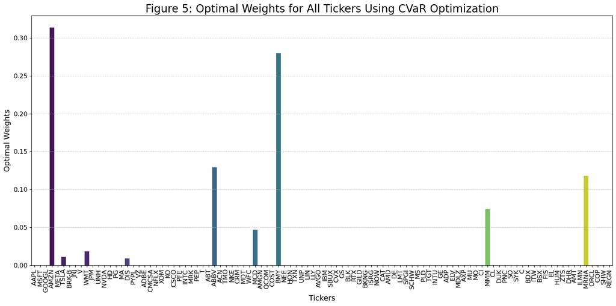

```python
# The optimal weights
optimal_weights_cvar = cvar_x.value

# Plot the optimal weights for all tickers
plt.figure(figsize=(16, 8))
sns.barplot(x=df.columns, y=optimal_weights_cvar, palette='viridis')
plt.xlabel('Tickers', fontsize=14)
plt.ylabel('Optimal Weights', fontsize=14)
plt.title('Figure 5: Optimal Weights for All Tickers Using CVaR Optimization', fontsize=20)
plt.xticks(rotation=90, fontsize=12)
plt.yticks(fontsize=12)
plt.grid(axis='y', linestyle='--', alpha=0.7)
plt.tight_layout()
plt.show()
```

```python
# Filter and print the tickers with weight greater than or equal to 0.1%
overweight_stocks_cvar = [(tickers[i], optimal_weights_cvar[i]) for i in range(len(tickers)) if optimal_weights_cvar[i] >= 0.001]

print("Tickers with weights >= 0.1%:")
for ticker, weight in overweight_stocks_cvar:
    print(f"{ticker}: {weight}")
```

```
Tickers with weights >= 0.1%:
AMZN: 0.31375032614233717
TSLA: 0.01105323239450624
WMT: 0.01840639959026849
DIS: 0.008904221620972066
ABBV: 0.12906920812540723
MCD: 0.046752364452085006
BMY: 0.28018982272383813
MMM: 0.07392051193682965
MRNA: 0.1179503266801373
```

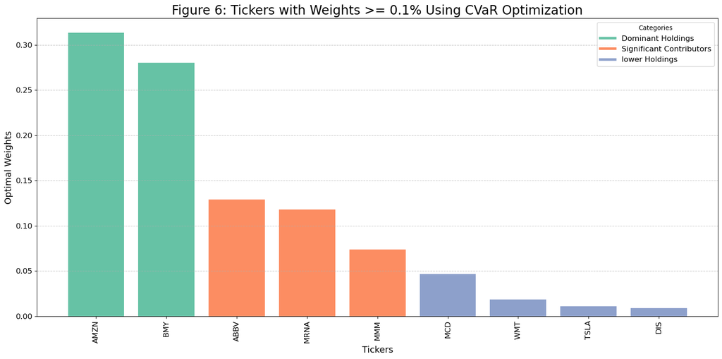

```python
# Sort the stocks by weight in descending order
overweight_stocks_sorted = sorted(overweight_stocks_cvar, key=lambda x: x[1], reverse=True)
plotted_ticker = [ticker for ticker, weight in overweight_stocks_sorted]
plotted_weight = [weight for ticker, weight in overweight_stocks_sorted]

# Define categories and colors
categories = {
    "Dominant Holdings": ["AMZN", "BMY"],
    "Significant Contributors": ["ABBV", "MRNA", "MMM"],
    "lower Holdings": ["MCD", "WMT", "TSLA", "DIS"],
}
colors = {
    "Dominant Holdings": sns.color_palette("Set2")[0],
    "Significant Contributors": sns.color_palette("Set2")[1],
    "lower Holdings": sns.color_palette("Set2")[2],
}

# Assign colors based on categories
ticker_colors = []
for ticker in plotted_ticker:
    for category, tickers in categories.items():
        if ticker in tickers:
            ticker_colors.append(colors[category])
            break

# Plot the data
plt.figure(figsize=(16, 8))
bars = plt.bar(plotted_ticker, plotted_weight, color=ticker_colors)

plt.xlabel('Tickers', fontsize=14)
plt.ylabel('Optimal Weights', fontsize=14)
plt.title('Figure 6: Tickers with Weights >= 0.1% Using CVaR Optimization', fontsize=20)
plt.xticks(rotation=90, fontsize=12)
plt.yticks(fontsize=12)
plt.grid(axis='y', linestyle='--', alpha=0.7)

# Create legend
legend_patches = [plt.Line2D([0], [0], color=color, lw=4) for color in colors.values()]
legend_labels = colors.keys()
plt.legend(legend_patches, legend_labels, title='Categories', fontsize=12)

plt.tight_layout()
plt.show()
```

### Outcomes:

#### 1. Weights Allocation (Figure 5):

This bar chart displays the optimal weights assigned to all 100 selected stocks in the portfolio using CVaR Optimization. Each bar represents a stock, and its height indicates the proportion of the total portfolio that should be invested in that stock.

- **Near-Zero Weights:** Just like Mean-Variance Optimization, Many stocks have weights that are shrinked to zero while using CVaR Optimization.
- **Overweight Stocks:** Stocks with higher weights are considered more favorable in the portfolio. *Amazon (AMZN)* and *Bristol-Myers Squibb (BMY)* stand out with the highest weights, approximately *31.37%* and *28.02%*, respectively. This suggests their stable and strong performance during the period considered. Other stocks with notable weights include *AbbVie (ABBV)*, *Moderna (MRNA)*, and *3M (MMM)*, also indicating their strong performance and lower risk. Compared to Mean-Variance Optimization's, overweight stocks in CVaR Optimization are less.

  Overweight Stocks list (Figure 6):
  1. **Amazon (AMZN)**: 31.37%
  2. **Bristol-Myers Squibb (BMY)**: 28.02%
  3. **AbbVie (ABBV)**: 12.91%
  4. **Moderna (MRNA)**: 11.80%
  5. **3M (MMM)**: 7.39%
  6. **McDonald's (MCD)**: 4.67%
  7. **Walmart (WMT)**: 1.84%
  8. **Tesla (TSLA)**: 1.11%
  9. **Disney (DIS)**: 0.89%

#### 2. Portfolio Analysis:

- **Dominant Holdings**: *Amazon (AMZN)* and *Bristol-Myers Squibb (BMY)* have the highest weights in the portfolio, with *Amazon* having approximately 31.37% and *Bristol-Myers Squibb* around 28.02%. These high weights suggest that these stocks are expected to provide strong and stable returns, making them key contributors to the portfolio's performance.
- **Significant Contributors**: Other stocks with notable weights include *AbbVie (ABBV)* at 12.91%, *Moderna (MRNA)* at 11.80%, and *3M (MMM)* at 7.39%. These stocks are significant contributors to the portfolio, indicating their potential for reliable performance and risk mitigation.
- **Lower Holdings**: Stocks such as *McDonald's (MCD)*, *Walmart (WMT)*, *Tesla (TSLA)*, and *Disney (DIS)* have weights ranging from approximately 0.89% to 4.67%. These companies, while still included in the portfolio, have a smaller proportion of the total investment.

## 3.2 Portfolio Simulation

```python
# Set the number of simulations and trading days
num_simulations_cvar = 10000
num_trading_days_cvar = 252

# Initial investment value
initial_portfolio_value_cvar = 1
```

```python
# Convert mean returns and covariance matrix for simulation
mean_returns_sim_cvar = np.array(mean_returns)
cov_matrix_sim_cvar = np.array(cov_matrix)
```

```python
# Simulate
simulated_portfolio_values_cvar = np.zeros(num_simulations_cvar)

for i in range(num_simulations_cvar):
    # Generate random daily returns based on the mean and covariance
    simulated_daily_returns_cvar = np.random.multivariate_normal(mean_returns_sim_cvar, cov_matrix_sim_cvar, num_trading_days_cvar)

    # Calculate the daily portfolio returns using the optimized weights from CVaR optimization
    portfolio_daily_returns_cvar = np.dot(simulated_daily_returns_cvar, optimal_weights_cvar)

    # Calculate the portfolio value at the end of the period
    portfolio_value_cvar = initial_portfolio_value_cvar * np.prod(1 + portfolio_daily_returns_cvar)
    simulated_portfolio_values_cvar[i] = portfolio_value_cvar
```

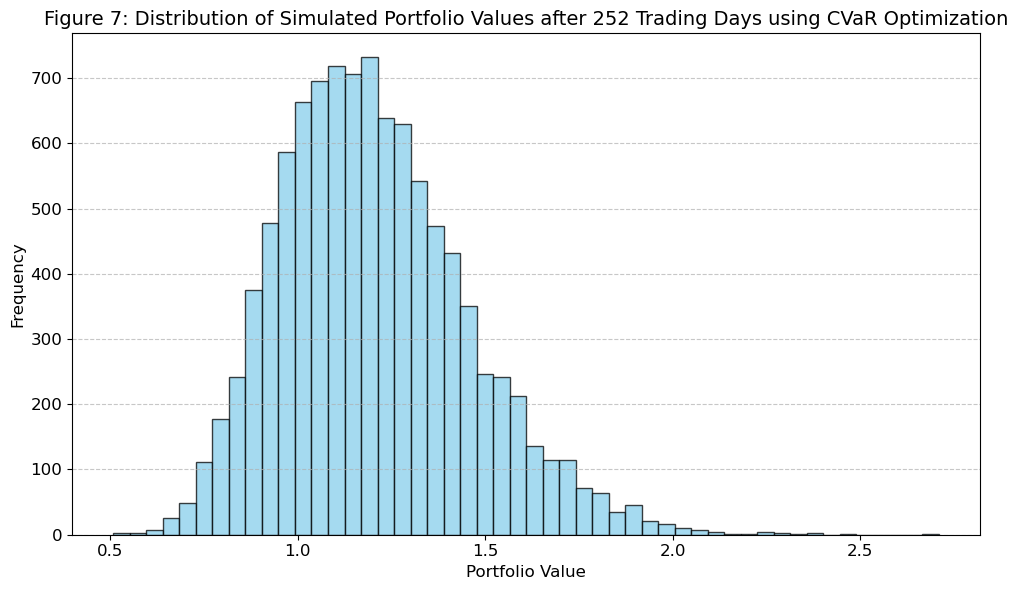

```python
# Plot the histogram of the portfolio values
plt.figure(figsize=(10, 6))
plt.hist(simulated_portfolio_values_cvar, bins=50, edgecolor='black', alpha=0.75, color='skyblue')
plt.xlabel('Portfolio Value', fontsize=12)
plt.ylabel('Frequency', fontsize=12)
plt.title('Figure 7: Distribution of Simulated Portfolio Values after 252 Trading Days using CVaR Optimization', fontsize=14)
plt.grid(axis='y', linestyle='--', alpha=0.7)
plt.xticks(fontsize=12)
plt.yticks(fontsize=12)
plt.tight_layout()
plt.show()
```

```python
# Statistics summary
mean_simulated_value_cvar = np.mean(simulated_portfolio_values_cvar)
std_dev_simulated_value_cvar = np.std(simulated_portfolio_values_cvar)
print(f"Mean Portfolio Value: {mean_simulated_value_cvar}")
print(f"Standard Deviation of Portfolio Value: {std_dev_simulated_value_cvar}")
```

```
Mean Portfolio Value: 1.2035778666888541
Standard Deviation of Portfolio Value: 0.250349824019324
```

#### Conclusion

# Comparison of Mean-Variance Optimization (MVO) and Conditional Value-at-Risk (CVaR) Optimization

**1. Objective:**

- **MVO:** Aims to balance the expected return and risk (variance) of the portfolio. It focuses on achieving an optimal trade-off between risk and return.
- **CVaR:** Seeks to minimize the expected shortfall beyond a specified confidence level, focusing on reducing extreme downside risks.

**2. Portfolio Composition:**

- **MVO:** Tends to produce a more diversified portfolio with weights spread across a larger number of stocks. This diversification helps to balance the risk-return trade-off. In the MVO analysis, the portfolio included a mix of stable, high-performing stocks from various sectors, such as *Walmart (WMT)* and *Verizon (VZ)*, which had the highest weights, indicating their strong performance and stability.
- **CVaR:** Results in a more concentrated portfolio with significant weights on fewer stocks. This concentration reflects a strategy to minimize potential extreme losses by focusing on the most resilient stocks. The CVaR analysis showed a heavy concentration on a few key stocks like *Amazon (AMZN)* and *Bristol-Myers Squibb (BMY)*, reflecting their perceived lower risk in adverse conditions.

**3. Risk Management:**

**5. Key Holdings:**

- **MVO:** Typically includes a mix of stable, high-performing stocks from various sectors. In this analysis, stocks like *Walmart (WMT)* and *Verizon (VZ)* had the highest weights, indicating their strong performance and stability. Other notable stocks included *McDonald's (MCD)*, *Merck (MRK)*, and *AbbVie (ABBV)*.
- **CVaR:** Concentrates heavily on a few key stocks deemed most resilient against extreme risks. Here, *Amazon (AMZN)* and *Bristol-Myers Squibb (BMY)* were significantly overweighted, reflecting their perceived lower risk in adverse conditions. Other significant holdings included *AbbVie (ABBV)*, *Moderna (MRNA)*, and *3M (MMM)*.

# Appendix

## 100 Selected Stocks and Their Company Names

1. **AAPL** - Apple Inc.
2. **MSFT** - Microsoft Corporation
3. **GOOGL** - Alphabet Inc. (Class A)
4. **AMZN** - Amazon.com Inc.
5. **META** - Meta Platforms, Inc.
6. **TSLA** - Tesla, Inc.
7. **BRK-B** - Berkshire Hathaway Inc. (Class B)
8. **JNJ** - Johnson & Johnson
9. **V** - Visa Inc.
10. **WMT** - Walmart Inc.
11. **JPM** - JPMorgan Chase & Co.
12. **UNH** - UnitedHealth Group Incorporated
13. **NVDA** - NVIDIA Corporation
14. **HD** - The Home Depot, Inc.
15. **PG** - Procter & Gamble Co.
16. **MA** - Mastercard Incorporated
17. **DIS** - The Walt Disney Company
18. **PYPL** - PayPal Holdings, Inc.
19. **VZ** - Verizon Communications Inc.
20. **ADBE** - Adobe Inc.
21. **CMCSA** - Comcast Corporation
22. **NFLX** - Netflix, Inc.
23. **XOM** - Exxon Mobil Corporation
24. **KO** - The Coca-Cola Company
25. **CSCO** - Cisco Systems, Inc.
26. **PFE** - Pfizer Inc.
27. **INTC** - Intel Corporation
28. **MRK** - Merck & Co., Inc.
29. **PEP** - PepsiCo, Inc.
30. **T** - AT&T Inc.
31. **ABT** - Abbott Laboratories
32. **ABBV** - AbbVie Inc.
33. **ACN** - Accenture plc
34. **TMO** - Thermo Fisher Scientific Inc.
35. **NKE** - NIKE, Inc.
36. **CRM** - Salesforce, Inc.
37. **MDT** - Medtronic plc
38. **WFC** - Wells Fargo & Company
39. **MCD** - McDonald's Corporation
40. **AMGN** - Amgen Inc.
41. **QCOM** - QUALCOMM Incorporated
42. **COST** - Costco Wholesale Corporation
43. **BMY** - Bristol-Myers Squibb Company
44. **NEE** - NextEra Energy, Inc.
45. **HON** - Honeywell International Inc.
46. **TXN** - Texas Instruments Incorporated
47. **UNP** - Union Pacific Corporation
48. **LIN** - Linde plc
49. **LLY** - Eli Lilly and Company
50. **AVGO** - Broadcom Inc.
51. **IBM** - International Business Machines Corporation
52. **SBUX** - Starbucks Corporation
53. **CVX** - Chevron Corporation
54. **GS** - The Goldman Sachs Group, Inc.
55. **BLK** - BlackRock, Inc.
56. **RTX** - Raytheon Technologies Corporation
57. **GILD** - Gilead Sciences, Inc.
58. **BKNG** - Booking Holdings Inc.
59. **ISRG** - Intuitive Surgical, Inc.
60. **NOW** - ServiceNow, Inc.
61. **CAT** - Caterpillar Inc.
62. **AMD** - Advanced Micro Devices, Inc.
63. **DE** - Deere & Company
64. **LMT** - Lockheed Martin Corporation
65. **SPGI** - S&P Global Inc.
66. **SCHW** - The Charles Schwab Corporation
67. **MS** - Morgan Stanley
68. **PLD** - Prologis, Inc.
69. **TGT** - Target Corporation
70. **INTU** - Intuit Inc.
71. **GE** - General Electric Company
72. **ADP** - Automatic Data Processing, Inc.
73. **ELV** - Elevance Health, Inc.
74. **MDLZ** - Mondelez International, Inc.
75. **AXP** - American Express Company
76. **MU** - Micron Technology, Inc.
77. **MO** - Altria Group, Inc.
78. **CI** - Cigna Group
79. **MMM** - 3M Company
80. **CL** - Colgate-Palmolive Company
81. **DUK** - Duke Energy Corporation
82. **PNC** - The PNC Financial Services Group, Inc.
83. **SO** - The Southern Company
84. **SYK** - Stryker Corporation
85. **C** - Citigroup Inc.
86. **BDX** - Becton, Dickinson and Company
87. **ITW** - Illinois Tool Works Inc.
88. **BSX** - Boston Scientific Corporation
89. **FIS** - Fidelity National Information Services, Inc.
90. **EL** - The Estée Lauder Companies Inc.
91. **HUM** - Humana Inc.
92. **ZTS** - Zoetis Inc.
93. **DHR** - Danaher Corporation
94. **AMT** - American Tower Corporation
95. **ILMN** - Illumina, Inc.
96. **MRNA** - Moderna, Inc.
97. **ORCL** - Oracle Corporation
98. **COP** - ConocoPhillips
99. **SHW** - The Sherwin-Williams Company
100. **REGN** - Regeneron Pharmaceuticals, Inc.

## Citations

- Boyd, S., Busseti, E., Diamond, S., Kahn, R. N., Koh, K., Nystrup, P., & Speth, J. (2017). Multi-period trading via convex optimization. Foundations and Trends® in Optimization, 3(1), 1-76.
- Cornuéjols, G., & Tütüncü, R. (2006). Optimization methods in finance. Cambridge University Press.

## Chat-GPT Prompts

1. Enhanced the plot visualization based on the code and graph I've provided.
2. Improve the overall coherence of this following paragraph.
3. Restructure this sentence to make it clearer or more concise.
4. Rewrite this sentence using more descriptive and statistical language.
5. Convert the formulations in this image to Markdown format.
6. Debug the following code.
7. Select 100 stocks in US stock market which are suitable for stock portfolio analysis, and provide the selection criterion.